# Beyond the Bar Graph

## Wisconsin Research Analyst Gathering, October 2014

Jared Knowles  
Research Analyst, Wisconsin DPI

## The Problem of Data Visualization

- Data use is increasing rapidly within the education space
- Policymakers are under increasing pressure to use data to inform decisions, justify funding, and guide practice
- **But,** policymakers are often **not** statisticians, researchers, or quants
- **Data visualization** is a way to bridge this gap
- Proper data visualization will bring the data to the audience in a way they can understand quickly and use to inform decisions

## What is dataviz?

Data visualization is a tool for communicating a specific feature of a datset in an approachable and efficient manner

## Student Growth

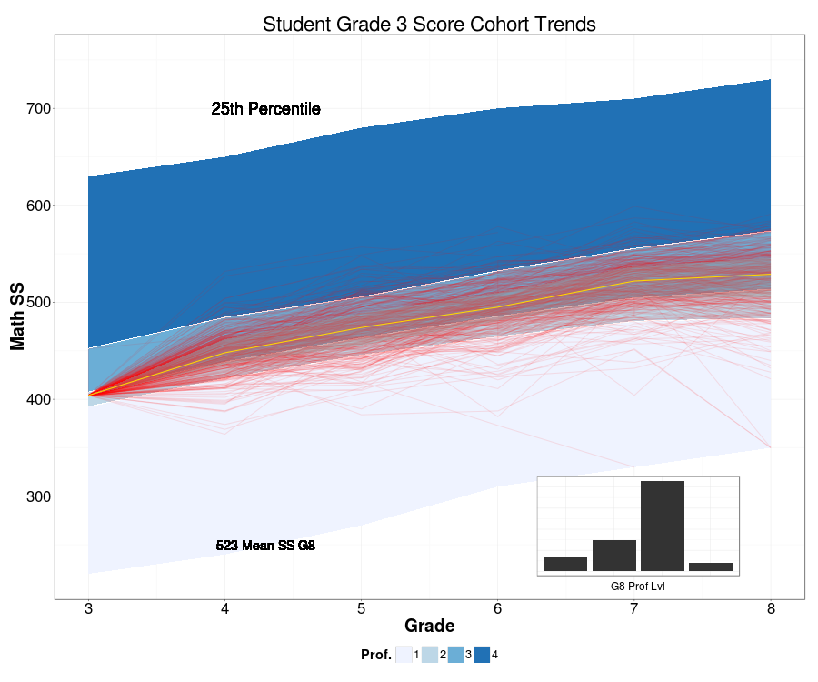

## Objectives

1. Review data visualization principles
2. Look at applications in education data
3. Best practices and advice
4. Review tools to use
5. Activity!

## Example

How can we improve this simple scatterplot?

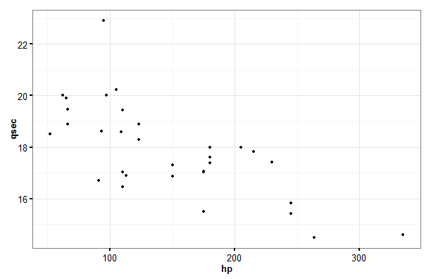

## Principles

## Chart Elements

There are a few things that all charts need [most of the time!]:

- **Axis labels** and a **title**
  - These make the chart self-explanatory
- A **legend**
  - What is the unit in the graphic?
- A **scale**
  - How are units mapped to the visual space
- **Annotations**
  - Author and data source (depending on distribution)

> These add up to provide context and meaning to viewers who have not analyzed the dataset themselves.

## Dimensions

- Charts and data are made up of dimensions (e.g. a bar chart is *x* and *y*)
- Additional dimensions can be represented by additional aesthetics or chart elements (e.g. color, size, shape, etc.)
- Dimensions can also be shown by multiple plots (e.g. a filmstrip)
- **Smart use of dimensions allows us to increase the information density of our charts**

[output not shown]

How you turn dimensions in the data into visual cues for your audience is everything.

## Reviewing Chart Types

## Stacked Bar

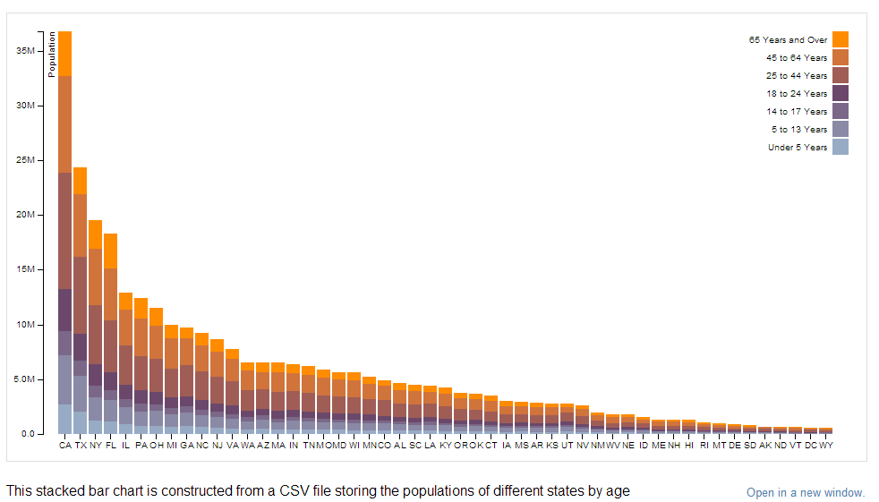

## Box and Whisker

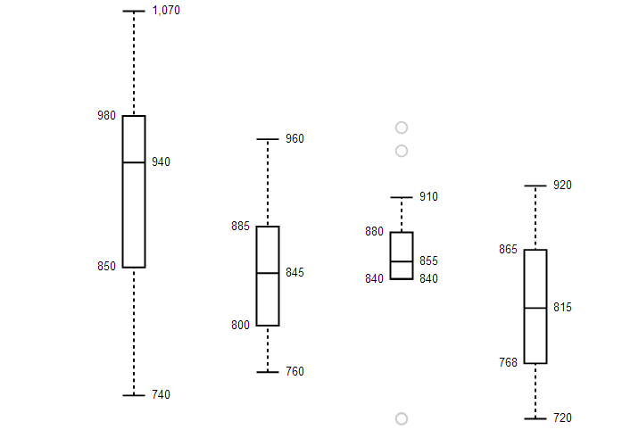

## Bullet Chart

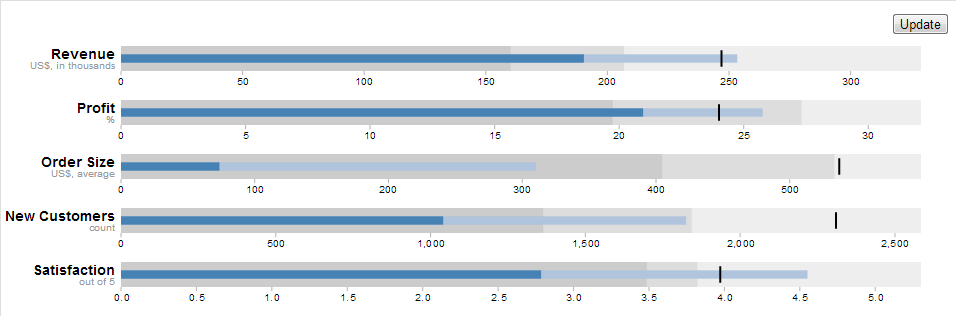

## Calendar

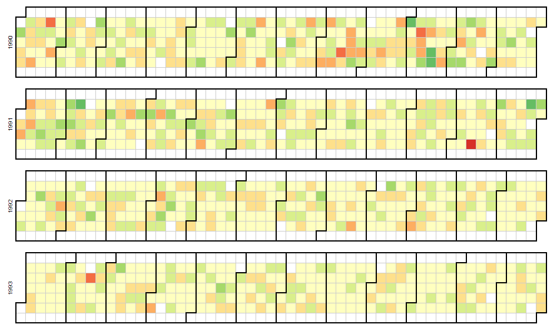

## Lines

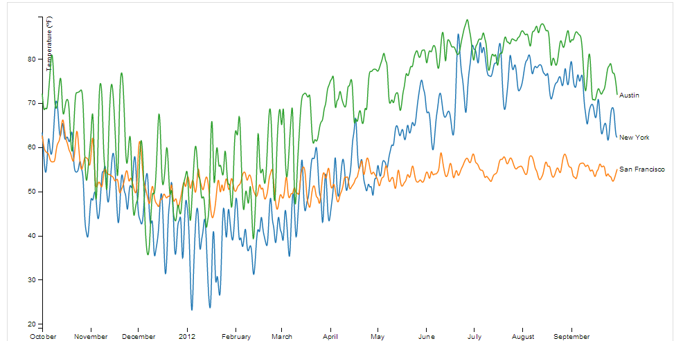

## Parallel Sets

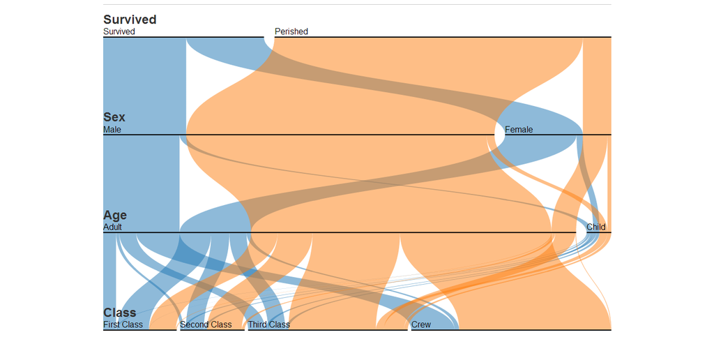

## Tree Map

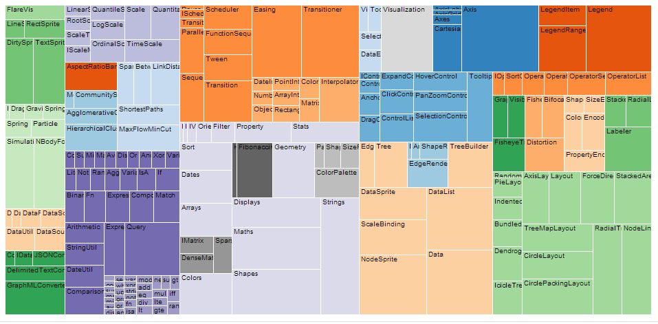

## Word Cloud

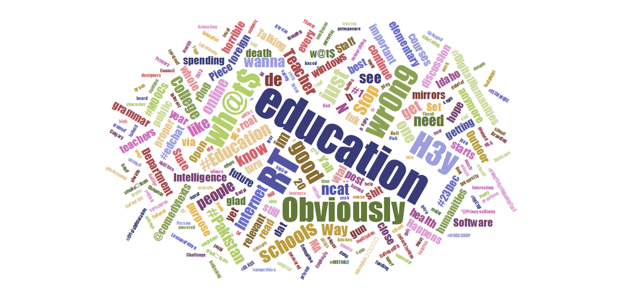

## Data Types

- Any given dimension may be measured at different [levels of measure](http://en.wikipedia.org/wiki/Level_of_measurement) [derived by Stanley Smith Stevens in the 1940s and 50s]
  - Nominal: unordered categories of data (e.g. race)
  - Ordinal: ordered categories of data, relative size and degree of difference between categories is unknown (e.g. Likert scales, proficiency levels, etc.)
  - Interval: ordered categories of data, fixed width (e.g. grade level in school, GPA)
  - Continuous (ratio): a measurement scale in a continuous space with a meaningful zero (e.g. scale scores)

## Mapping Levels of Measure to Visual Cues

### Aesthetics for Mapping

How do we map levels of measurement onto visual features of charts?

| Aesthetic | Discrete | Continuous |
| --- | --- | --- |
| Color | Disparate colors | Sequential or divergent colors |
| Size | Unique size for each value | mapping to radius of value |
| Shape | A shape for each value | *does not make sense* |

### Ordered vs. Unordered

| Aesthetic | Ordered | Unordered |
| --- | --- | --- |
| Color | Sequential or divergent colors | Rainbow |
| Size | Increasing or decreasing radius | *does not make sense* |
| Shape | *does not make sense* | A shape for each value |

## Some tips

- Focus on the content and the context
- Know your audience, understand their limits, then push them!
- Use best practices, except when they don't help
- Experiment and iterate!

## Charting Categorical Data

[figure not shown]

## Charting Ordinal Data

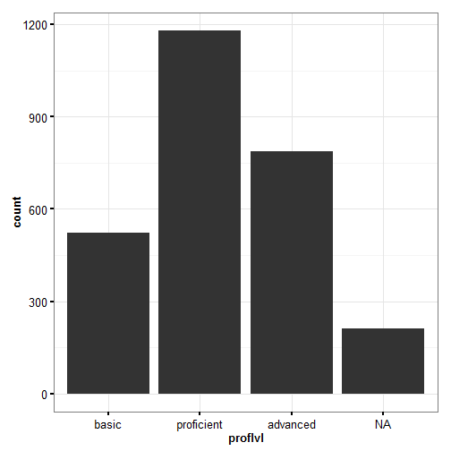

## Charting Interval/Continuous Data

```
## stat_bin: binwidth defaulted to range/30. Use 'binwidth = x' to adjust this.
```

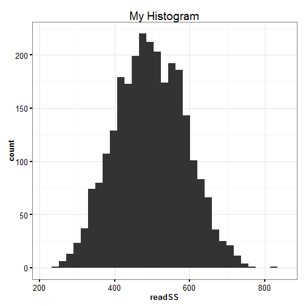

Think like a map. Data density and easy interpretability.

## Maps

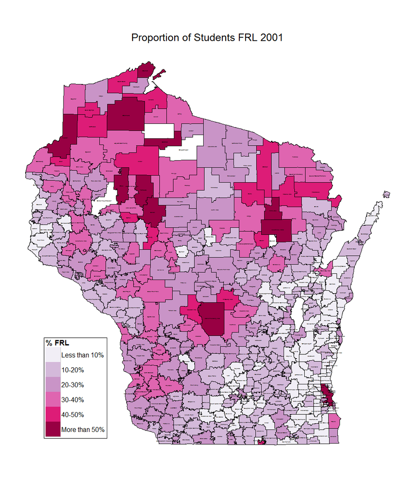

## Complexity

How do we display thousands or hundreds of thousands of observations with varying data types across multiple dimensions?

1. **Summarize the data**
   - Display summary statistics visually depicting the central tendency and spread of data
2. **Plot the raw data**
   - Annotate wisely to display the main message
3. **Model the data**
   - Use a statistical model to summarize features of the data

Let's look at some examples of this.

## Summarizing Data

- The most simple summaries are measures of central tendency, most easily understood
- It is important to look at the spread of data too though
- If time is of interest, we are interested in trends
- If space is of interest, we are interested in maps or spatial distributions
- **Think about context and reference**
- Let's look at an example summarizing student data to schools!

## Plotting Means

[output not shown]

[output not shown]

## Mistakes

## Adding a Dimension

[output not shown]

[output not shown]

## Even More Dimensions

[output not shown]

## Annotation

[output not shown]

## Caterpillar Plots

[output not shown]

## Raw Data

Sometimes, we can get away with showing the raw data, that is, all data points. We may want to do this for a few reasons:

- the "wow" effect,
- because it is easier,
- or because it looks better aesthetically.

How could it be done?

## 600,000 Observations Too Many

[output not shown]

## Strategies for Presenting Big Data

- Without reducing the data points we need to do one or more of three things to be successful
1. Spread the data out
2. Bin the data into groups
3. Annotate and add references

## Spreading the Data Out

1. **Repeat the plot for subgroups**
   - Allow the viewer to draw comparisons across small plots
2. **Reduce the ink**
   - Each point has too much "weight", so make them weigh less
3. **Add Reference Points**
   - 600,000 observations in one panel is not meaningful and overwhelms the viewer
- Edward Tufte and others recommend **small multiples**, a technique of repeating a plot across groups to compare relationships in multiple dimensions

## What About This

[output not shown]

## Even Smaller Multiples

[output not shown]

## Binning Data

[output not shown]

## Modeling the Data

All models are wrong. Some models are useful.

## Smoothers

[output not shown]

## Comparing Model Performance

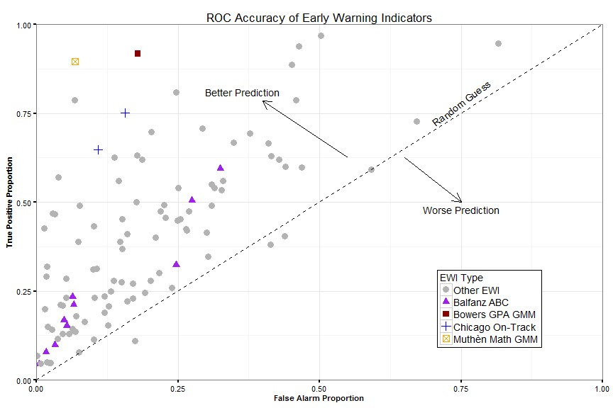

## Aiding in Model Choice

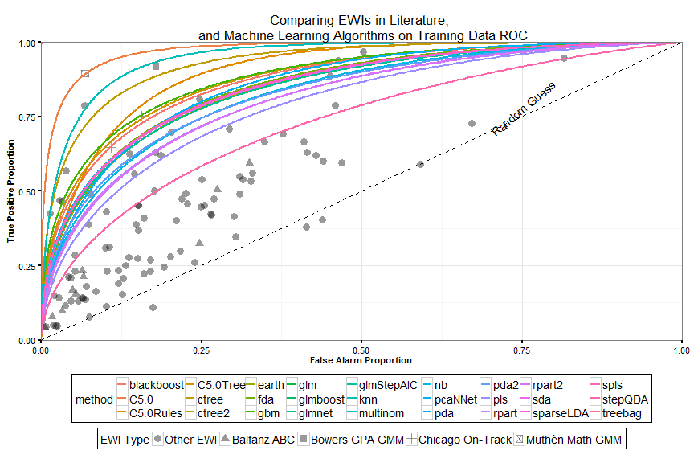

## Regression Trees

[figure not shown]

## Regression Results

[figure not shown]

## Coefficient Comparisons

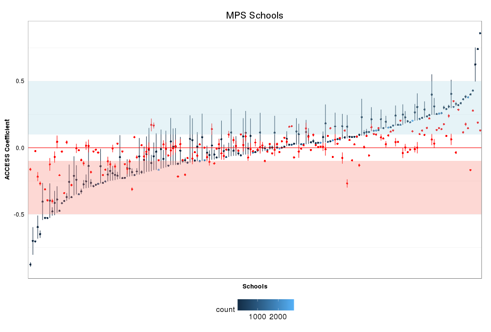

## Path Diagrams

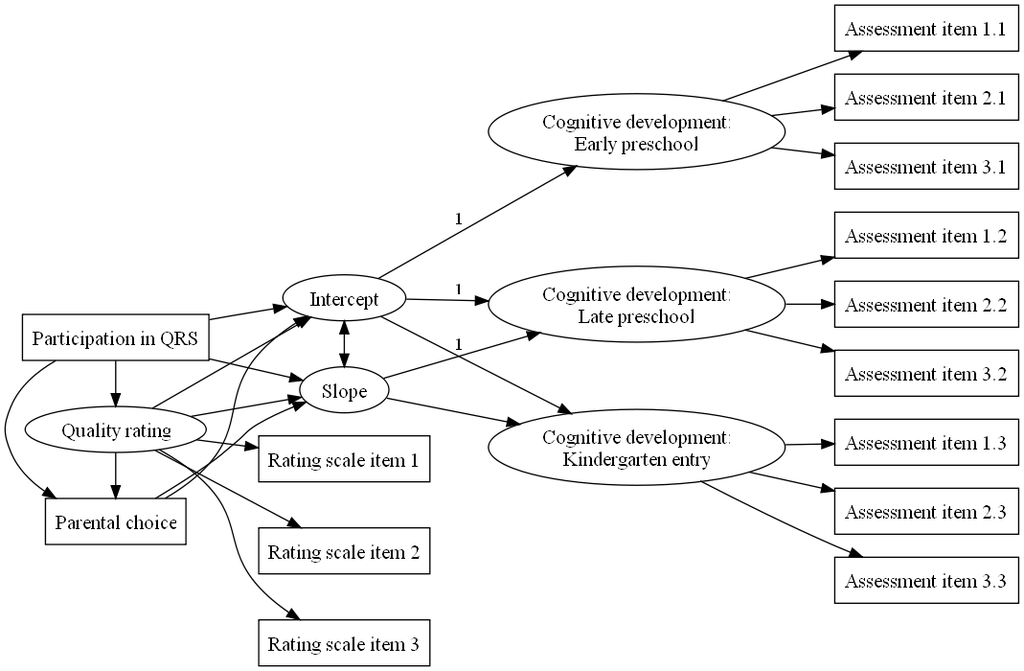

## Illustrating a Model through Simulation

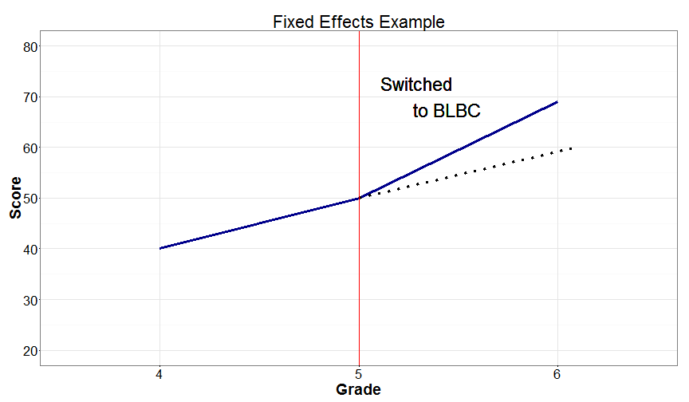

## Simulating Outcomes

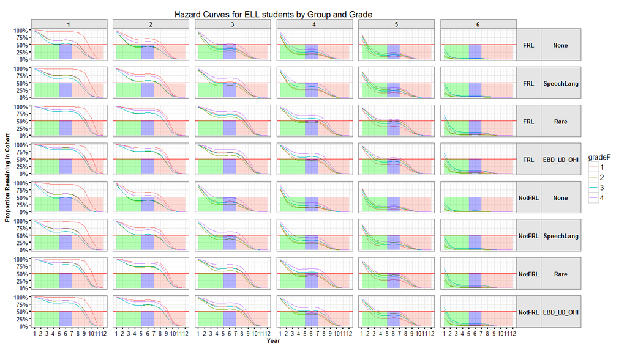

## Combining Features

We can combine these features.

- Facets with smoother lines for references (small multiples + models)
- Summary plots with raw data in the background
- Reference lines and group comparisons

## Animation Example

[figure not shown]

## Why does this work?

- Annotation
- Labeling
- Lots of data-ink
- Reference points galore

## Some tips

- Have a properly chosen format and design
- Use words, numbers and drawing together
- Reflect a balance, a proportion, relevant scale
- Display an accessible complexity of details
- Have a narrative quality, tell a story
- Avoid content-free decoration (Tufte's proverbial chartjunk)
- Draw in a professional manner with an eye on the technical details
- Provide your audience with the context they need and remember they haven't lived in the data like you!

## Themes

They can **communicate**, **confound**, **brand**, and **distract**

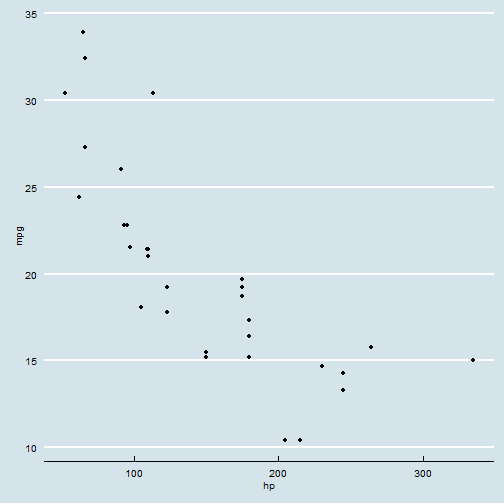

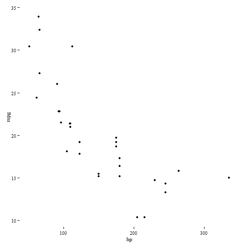

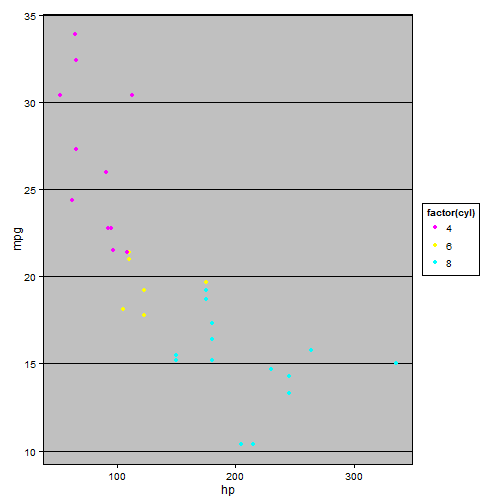

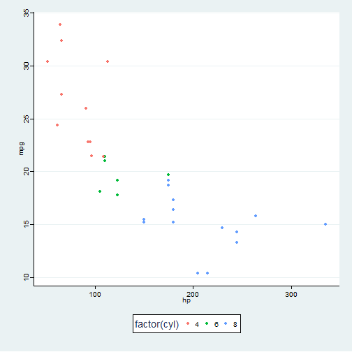

## Technical Details

## Graphics Files

## Technologies

The technology you choose to do visualizations is largely a question of personal productivity, but with some important caveats:

- In the future, more and more content is going to be delivered in a paperless world, so pick a technology that can leverage web/tablet/phone interfaces
- Different technologies are useful for different levels of finish and polish; Adobe Illustrator is great for publication quality graphics, R is a great tool for rapidly prototyping different visualizations
- Chose a technology that best serves your **consumer**, not you the producer. Charts are a service to the consumer, not to the creator.

## Some Technologies

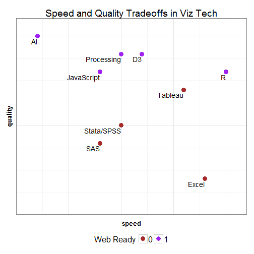

## Programming vs. Illustrating

Keep in mind that depending on the project you may need to programatically make data visualizations, or you may need a highly customized illustrated graphic.

## Beyond Graphics

We have a number of other techniques we can use beyond simple charts.

- Animations
- Interactive demos
- Summary tables
- Videos
- Web sites
- Simulations

## References

- Tufte, Edward. 1992. [The Visual Display of Quantitative Information.](http://www.amazon.com/The-Visual-Display-Quantitative-Information/dp/0961392142/) Graphics Press.
- Unwin, Theus, and Hofmann. 2006. [Graphics of Large Datasets: Visualizing a Million.](http://www.amazon.com/Graphics-Large-Datasets-Visualizing-Statistics/dp/0387329064) Springer.
- Wilkinson, Leland. 2005. The Grammar of Graphics. Springer.
- Ware, Colin. 2012. [Information Visualization: Perception for Design.](http://www.amazon.com/Information-Visualization-Third-Edition-Technologies/dp/0123814642/ref=reg_hu-rd_add_1_dp) 3rd Edition. Morgan Kaufmann.
- Cleveland, William. 1994. [The Elements of Graphing Data.](http://www.amazon.com/gp/product/0963488414/) Hobart Press.
- Cleveland, William. 1993. [Visualizing Data.](http://www.amazon.com/gp/product/0963488406) Hobart Press.

## References

- Few, Stephen. 2009. [Now You See It: Simple Visualization Techniques for Quantiative Analysis.](http://www.amazon.com/gp/product/0970601980/) Analytics Press.
- Few, Stephen. 2012. [Show Me the Numbers: Designing Tables and Graphs to Enlighten.](http://www.amazon.com/gp/product/0970601972) Analytics Press.
- Yau, Nathan. 2011. [Visualize This: The FlowingData Guide to Design, Visualization, and Statistics.](http://www.amazon.com/Visualize-This-FlowingData-Visualization-Statistics/dp/0470944889/) Wiley.
- Few, Stephen. 2006. [Information Dashboard Design: The Effective Visual Communication of Data.](http://www.amazon.com/Information-Dashboard-Design-Effective-Communication/dp/0596100167) O'Reilly Media

## Where to Learn Online?

- [Andy Kirk](http://www.visualisingdata.com)
- [D3](http://d3js.org/)
- [The Functional Art](http://www.thefunctionalart.com/)
- [ggplot2](http://www.ggplot2.org)
- [Robert Kosara](http://eagereyes.org/about)
- [Data Stories Podcast](http://datastori.es/)

## Review of Key Concepts

## Contact Information

- DEWS Homepage: http://wise.dpi.wi.gov/wisedash_dews
- E-mail: jared.knowles@dpi.wi.gov / jknowles@gmail.com
- GitHub: http://www.github.com/jknowles
- Homepage: [www.jaredknowles.com](http://www.jaredknowles.com/)
- Google+: https://plus.google.com/+JaredKnowles

[figure not shown]

## For Fun

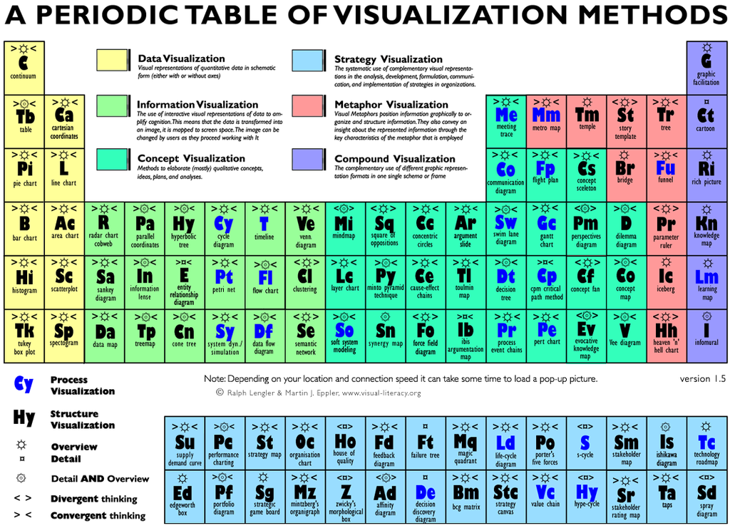